# Untitled

Nicholas Nagle

March 7, 2015

### Two-sample T-test

1. Two-sample T-test> ACT scores Consider the hypothesis that college-bound males and females have the same average ACT scores.

```r
library('ggplot2')
library('tidyr')
library('dplyr')
library('Sleuth3')
setwd('F:/Documents/Geography_415/dpaulse1/homework4')
act <- read.table('ACT_scores.txt', header=TRUE)
act2 <- gather(act, key=Sex, value=Score)
rm(act)
```

1. Write out the hypothesis that is tested by a two-sample t-test in this case.
- The hypothesis being tested in this case is whether or not there is a statistically significant difference in ACT scores between Males and Females.
2. Using boxplots and summary statistics, report on the suitability of these data for a two-sample t-test to evaluate the hypothesis.

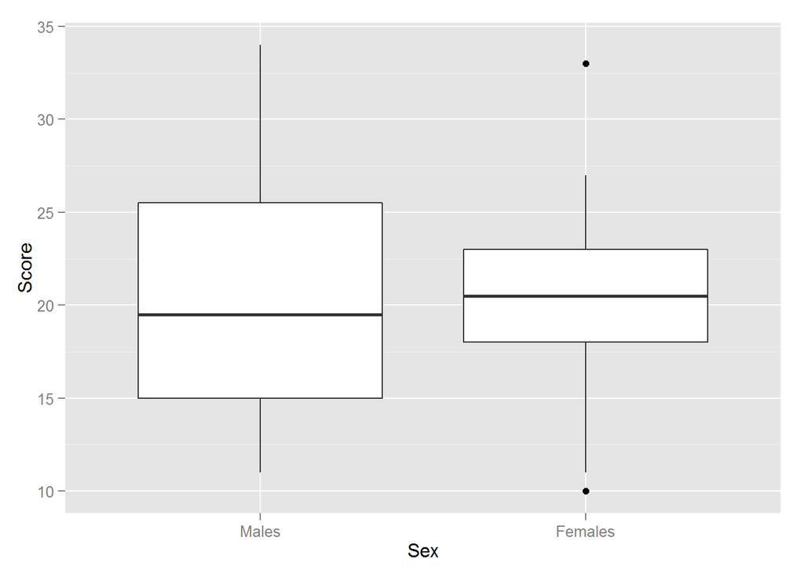

```r
ggplot(act2) + geom_boxplot(aes(x=Sex, y=Score))
```

```r
act2 %>% group_by(Sex) %>% summarize(Mean=mean(Score), Median=median(Score),
  'Std Dev'=sd(Score), N=n())
```

```
## Source: local data frame [2 x 5]
##
##       Sex     Mean Median  Std Dev  N
## 1   Males 20.85714   19.5 7.998626 14
## 2 Females 20.42857   20.5 6.198192 14
```

- Based upon the boxplots and the summary statistics, I would say the groups are fairly similar and would expect the two-sample t-test to produce a result with a low t-value and high p-value. The variances of the two genders are similar enought that this type of analysis can be performed.
3. Conduct a t-test to evaluate the hypothesis.

```r
t.test(Score~Sex, data=act2)
```

```
##
##  Welch Two Sample t-test
##
## data:  Score by Sex
## t = 0.1585, df = 24.475, p-value = 0.8754
## alternative hypothesis: true difference in means is not equal to 0
## 95 percent confidence interval:
##  -5.147383  6.004526
## sample estimates:
##   mean in group Males mean in group Females
##              20.85714              20.42857
```

- Based upon the very low t-value and the high p-value, we have evidence to confirm the hypothesis that there is no difference in test scores between Males and Females.
2. Two-sample t-tests. Cloud Seeding.

These data were collected in Southern Florida between 1968 and 1972 to test a hypothesis that seeding silver iodide into clouds can promote rainfall. They appear in a number of intriductory texts, including a favorite intermediate text of mine: Ramsay and Schafer’s The Statistical Sleuth. The data contain 52 weather events that were deemed suitable for seeding. On each day an airplane flew the clouds and a payload was released. It was randomly determined whether the payload would contain silver iodide or not, but the pilots were unaware of this, i.e. the pilots were blind to the treatment. Following the flight, radar was used to measure the precipitation falling from the cloud (in units of acre-feet).

```r
library(Sleuth3)
# Here are two ways to calculate a boxplot
# boxplot(Rainfall~Treatment, data=case0301)
# library(ggplot2)
# ggplot(data=case0301) + geom_boxplot(aes(x=Treatment, y=Rainfall))

# Here are two ways to calculate some summary statistics
# tapply(X=case0301$Rainfall, INDEX=case0301$Treatment, FUN=mean) # Calculate mean, repeat for sd
# library(dplyr)
# case0301 %>% group_by(Treatment) %>% summarize(m=mean(Rainfall), sd=sd(Rainfall), n=n() )
seed <- case0301
```

1. What hypothesis is being tested?
- Here, the two-sample t-test will help determine if cloud seeding makes a significant difference in the amount of Rainfall.
2. Using boxplots and summary statistics, report on the suitability of these data for a two-sample t-test to evaluate the hypothesis that seeding influences rainfall.

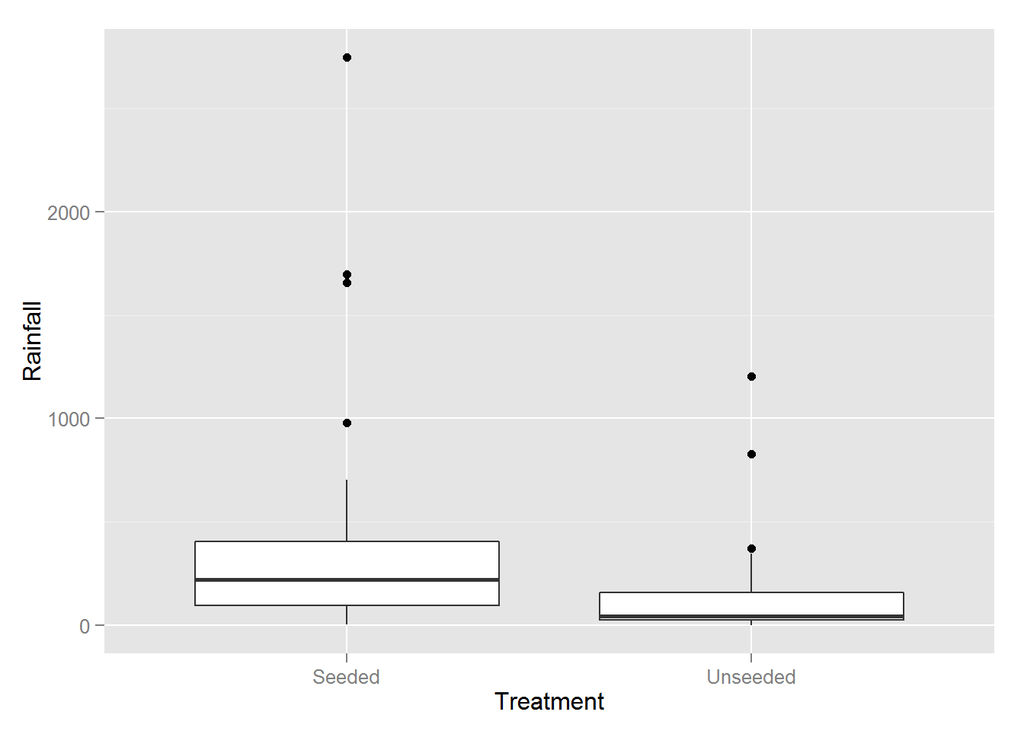

```r
ggplot(seed) + geom_boxplot(aes(x=Treatment, y=Rainfall))
```

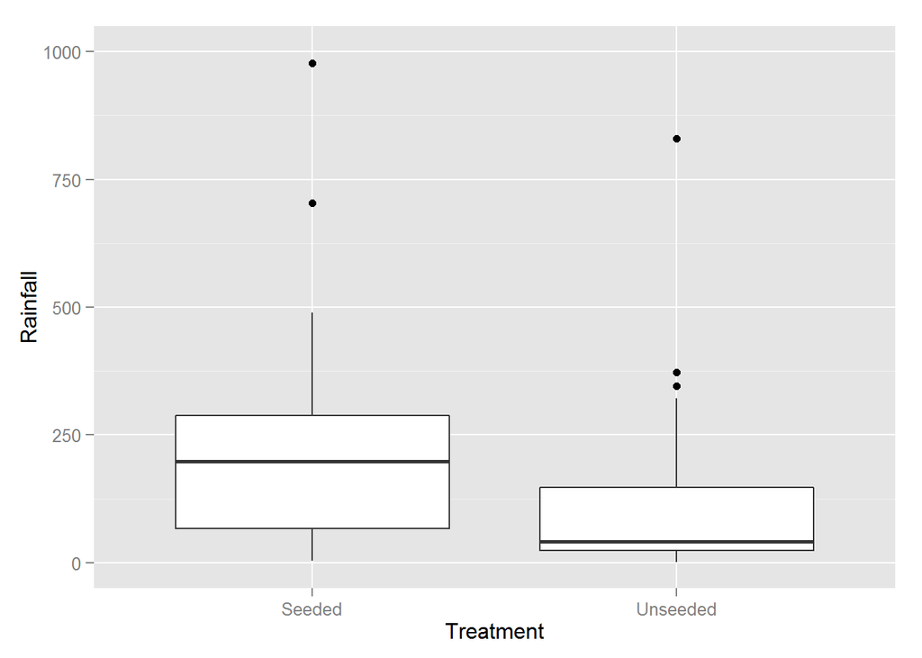

```r
# Because the results are kind of crammed down towards the bottom of the chart, I resized the bounds of the y-axis.
ggplot(seed) + geom_boxplot(aes(x=Treatment, y=Rainfall)) +
  scale_y_continuous(limits=c(0,1000))
```

```r
seed %>% group_by(Treatment) %>% summarize(Mean=mean(Rainfall),
  Median=median(Rainfall), 'Std Dev'=sd(Rainfall), N=n())
```

```
## Source: local data frame [2 x 5]
##
##   Treatment     Mean Median  Std Dev  N
## 1    Seeded 441.9846  221.6 650.7872 26
## 2  Unseeded 164.5885   44.2 278.4264 26
```

- Based upon the boxplots and the summary statistics, I would say it is possible that there a statistically significant difference between the treatment and control group. The boxplots are similar enought that there may not be though. Looking at the variances, I would think they are different enought that a different method may be more appropriate, but without a statistical test, I could not say for sure.
3. Conduct a t-test to evaluate the hypothesis that seeding influences rainfall and report the result.

```r
t.test(Rainfall~Treatment, data=seed)
```

```
##
##  Welch Two Sample t-test
##
## data:  Rainfall by Treatment
## t = 1.9982, df = 33.855, p-value = 0.05377
## alternative hypothesis: true difference in means is not equal to 0
## 95 percent confidence interval:
##   -4.764295 559.556603
## sample estimates:
##   mean in group Seeded mean in group Unseeded
##               441.9846               164.5885
```

- From the results of the two-sample t-test, the difference in Rainfall between the seeded and unseeded clouds is not significant at the 0.05 level. However, the t-value and p-value are very close to the cutoff. Therefore, I would say that cloud seeding does make a difference in the Rainfall, but it may not make as much of a difference as the scientists had hoped.
4. Repeat a., b., and c. using a log-transform of the rainfall measurement. Which analysis do you prefer and why?

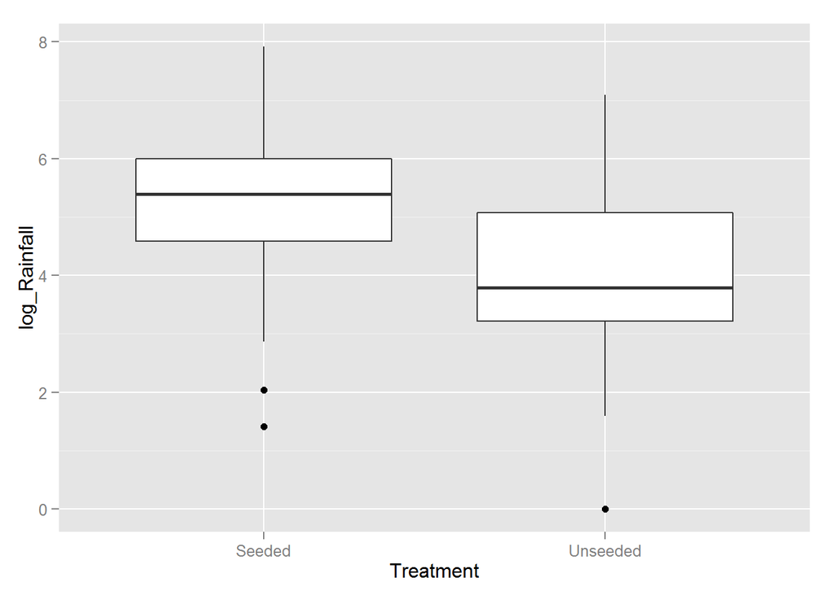

```r
seed$log_Rainfall <- log(seed$Rainfall)
ggplot(seed) + geom_boxplot(aes(x=Treatment, y=log_Rainfall))
```

```r
seed %>% group_by(Treatment) %>% summarize(Mean=mean(log_Rainfall),
  Median=median(log_Rainfall), 'Std Dev'=sd(log_Rainfall), N=n())
```

```
## Source: local data frame [2 x 5]
##
##   Treatment     Mean   Median  Std Dev  N
## 1    Seeded 5.134187 5.396406 1.599514 26
## 2  Unseeded 3.990406 3.786259 1.641847 26
```

```r
t.test(log_Rainfall~Treatment, data=seed)
```

```
##
##  Welch Two Sample t-test
##
## data:  log_Rainfall by Treatment
## t = 2.5444, df = 49.966, p-value = 0.01408
## alternative hypothesis: true difference in means is not equal to 0
## 95 percent confidence interval:
##  0.2408498 2.0467125
## sample estimates:
##   mean in group Seeded mean in group Unseeded
##               5.134187               3.990406
```

1. This time, the t-test is testing whether there is a difference in log(rainfall) between seeded and unseeded clouds.
2. Using log(rainfall), the boxplots look different enough that there will likely be a statistically signficant difference between the two groups. Also, the standard deviations are much more similar in this case, so I would feel more comfortable using this method of analysis.
3. Based upon the the results of the t-test (namely, the t-value and p-value), it appears that there is a statistically significant difference in log(rainfall) between the treatment and control group.
5. Why is it important that the pilots were unaware of whether they were seeding or not?
- If the pilots had known whether or not they were seeding, it could have produced a source of bias, which could skew results either in favor of or against the study.
6. Unfortunately, we do not have the date of the weather event. Why would it be helpful to have this information?
- It would be helpful to have the date of the weather events to determine how much rain fell in areas not in the treatment area. It is likely that some days were just more or less rainy than others and this could potentially produce misleading results.

### ANOVA

3. Temperatures among Seasons.

Here are some simple data describing average daily temperatures for different cities grouped by season.

```r
# Create a dataset
temp = c(60,65,62,64,63,80,85,82,84,83,90,95,101,99,100)
season = rep( c('Fall', 'Spring', 'Summer'), times=c(5,5,5))

temperature <- data.frame(Temperature=temp, Season=season)
rm(temp, season)
```

For the air temperature data, conduct an ANOVA and use the F-statistic to test the hypothesis that air temperature varies by season.

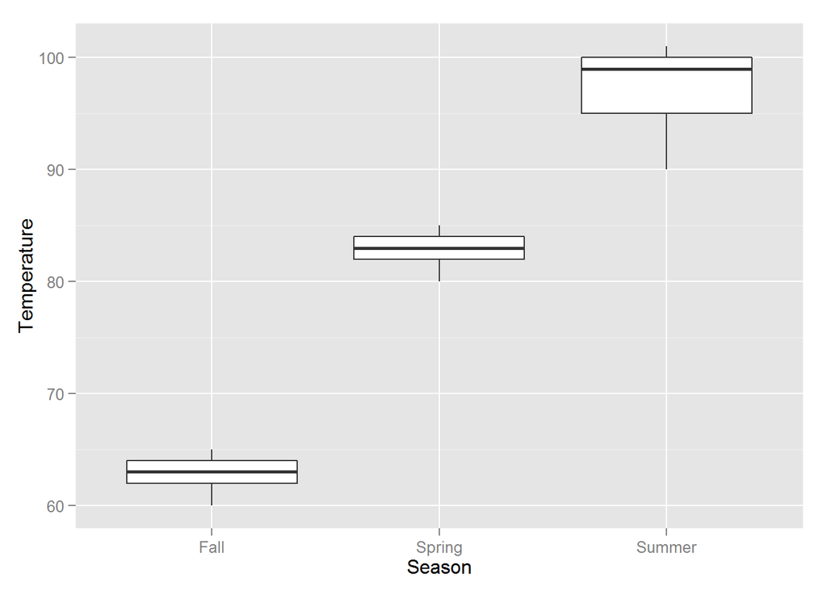

```r
ggplot(temperature) + geom_boxplot(aes(x=Season, y=Temperature))
```

```r
temperature %>% group_by(Season) %>% summarize(Mean=mean(Temperature),
  Median=median(Temperature), 'Std Dev'=sd(Temperature), N=n())
```

```
## Source: local data frame [3 x 5]
##
##   Season Mean Median  Std Dev N
## 1   Fall 62.8     63 1.923538 5
## 2 Spring 82.8     83 1.923538 5
## 3 Summer 97.0     99 4.527693 5
```

```r
summary(aov(Temperature~Season, data=temperature))
```

```
##             Df Sum Sq Mean Sq F value   Pr(>F)
## Season       2 2952.1  1476.1   158.7 2.34e-09 ***
## Residuals   12  111.6     9.3
## ---
## Signif. codes:  0 '***' 0.001 '**' 0.01 '*' 0.05 '.' 0.1 ' ' 1
```

- In this example, the Analysis of Variance (ANOVA) test is showing whether or not there is a statistically significant difference in temperature among three different seasons: Fall, Spring, and Summer.
- Based upon the the boxplots, there is a large difference in temperature among the three seasons. This is not surprising and indicates that it is likely that an ANOVA test would find a statistically significant difference. The three seasons’ variances are similar enough to perform this analysis.
- Based upon the ANOVA results, there is strong statisical evidence that there is a difference in temperature among the three different seasons (as we would expect). The F value is very high and the p-value is very low, showing that the difference in temperatures from season to season is much too high to be purely by chance.
4. Spock Conspiracy Trial.

This is another classic dataset. Dr. Benjamin Spock was a pediatrician who wrote a very popular book in 1948. In 1968, Dr Spock was accused of conspiring to violate the Selective Services Act by helping young men to medically avoid the military draft during the Vietnam War. His defence challeneged the case on the grounds that the jury did not contain a single woman, and therefore could not be random.

These data used here contain jury compositions for Spock’s judge and 6 other judges in the same court. For each jury, we have the fraction of the jury that was female.

```r
spock <- case0502
```

1. Qualitatively describe these data using boxplots and summary statistics.

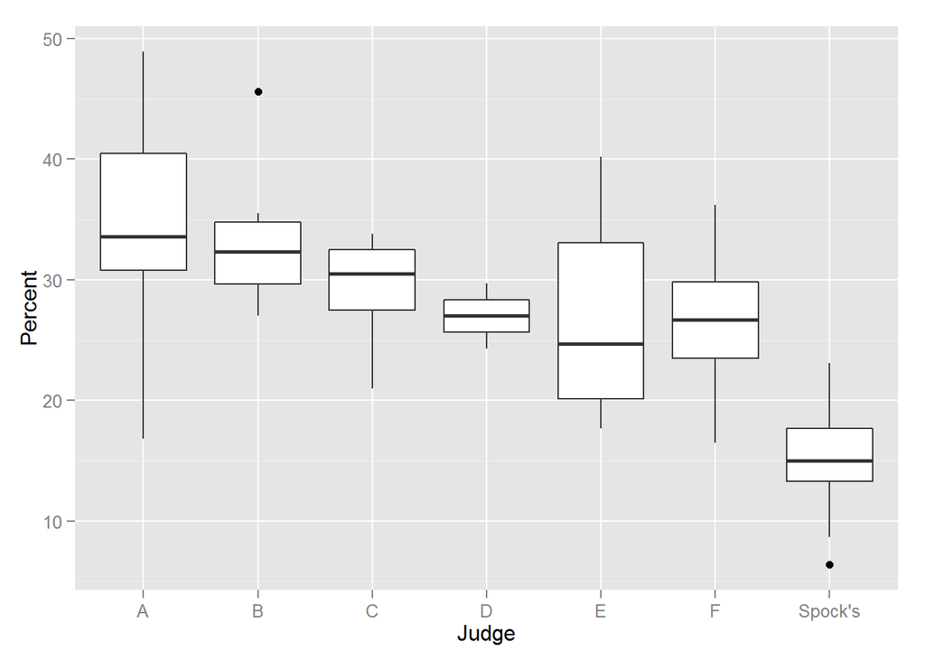

```r
ggplot(spock) + geom_boxplot(aes(x=Judge, y=Percent))
```

```r
spock %>% group_by(Judge) %>% summarize(Mean=mean(Percent),
  Median=median(Percent), 'Std Dev'=sd(Percent), N=n())
```

```
## Source: local data frame [7 x 5]
##
##     Judge     Mean Median   Std Dev N
## 1       A 34.12000  33.60 11.941817 5
## 2       B 33.61667  32.35  6.582224 6
## 3       C 29.10000  30.50  4.592929 9
## 4       D 27.00000  27.00  3.818377 2
## 5       E 26.96667  24.70  9.010142 6
## 6       F 26.80000  26.70  5.968878 9
## 7 Spock's 14.62222  15.00  5.038794 9
```

- From the boxplots, we can see that Spock’s judge frequently has a lower number of females on his juries (as compared to the other judges). We can see this from the summary statistics as well as all of the judges other than Spock’s had females making up and average of at least 26% females; however, Spock’s judge has an average of 14.6%. For the most part, all of the judges have similar amounts of variation, although A is somewhat larger (most likely due to the relatively smaller number of observations).
2. Using an ANOVA, test the hypothesis that all of the judges have the same jury compositions on average and report your results.

```r
summary(aov(Percent~Judge, data=spock))
```

```
##             Df Sum Sq Mean Sq F value  Pr(>F)
## Judge        6   1927   321.2   6.718 6.1e-05 ***
## Residuals   39   1864    47.8
## ---
## Signif. codes:  0 '***' 0.001 '**' 0.01 '*' 0.05 '.' 0.1 ' ' 1
```

- From the ANOVA results, we can see that at least one of the judges is significantly different in the percentage of females in their juries. Unfortunately, since this is only an ANOVA, there is no statistical evidence to confirm it was only Spock’s judge that was significantly different.
3. Grouping together Judges A-F, perform a two-sample t-test to test the hypothesis that Spock’s judge consistently chooses juries with lower than expected women.

```r
spock$Judge_Grp <- ifelse(spock$Judge=="Spock's", "Spock's", "Other")
t.test(Percent~Judge_Grp, data=spock)
```

```
##
##  Welch Two Sample t-test
##
## data:  Percent by Judge_Grp
## t = 7.1597, df = 17.608, p-value = 1.303e-06
## alternative hypothesis: true difference in means is not equal to 0
## 95 percent confidence interval:
##  10.49935 19.23999
## sample estimates:
##   mean in group Other mean in group Spock's
##              29.49189              14.62222
```

- From the two-sample t-test, we have statistical evidence (a high t-value and a very low p-value) to confirm that there is a significant difference between the percentage of women chosen by Spock’s judge as compared to the other judges.
4. Use another ANOVA to evaluate whether or not it was suitable to group together the other 6 judges.

```r
summary(aov(Percent~Judge_Grp=="Other", data=spock))
```

```
##                      Df Sum Sq Mean Sq F value   Pr(>F)
## Judge_Grp == "Other"  1   1601  1600.6   32.15 1.03e-06 ***
## Residuals            44   2191    49.8
## ---
## Signif. codes:  0 '***' 0.001 '**' 0.01 '*' 0.05 '.' 0.1 ' ' 1
```